# Value at Risk sur l’action ORPEA.PA

Alex FABRE

13/10/2020

Résumé : (9.1)

Ce projet est le premier d’une série de 2. Il s’agit dans celui-ci d’apprécier la spécification d’un modèle ARMA couplé à un modèle GARCH et de constater si la prise en compte d’un effet de levier est effective. Dans le prochain, nous développerons un modèle plus complexe (apARCH, eGARCH, iGARCH) afin d’établir la VaR et de réaliser le backtesting.

# 1 Données

J’ai choisi l’action ORPEA car j’ai travaillé sur cette société l’année dernière dans un projet d’analyse financière. Je trouve intéréssant d’étudier à nouveau cette entreprise. C’est la deuxième plus grande société française dans le domaine de la santé des personnes agées. L’année dernière j’avais observé qu’Orpea avait une stratégie de long terme unique en investissant dans ses bâtiments. Sans rentrer dans les détails, Orpea a une stratégie financière assez robuste mais elle est sujette aux critiques. En effet, les conditions de vie proposées ne sont pas toujours de la qualité prétendue. J’avais donc conclut qu’investir dans Orpea est un investissement qui peut mener à une valorisation non négligeable mais sous couvert d’un risque grave de l’apparition d’une polémique.

```r
first.date <- "2009-12-31"
last.date <- "2019-12-31"
freq.data <- 'daily'
type.return <- 'log'
tickers <- 'ORP.PA'
tab <- BatchGetSymbols(tickers = tickers,
                         first.date = first.date,
                         last.date = last.date,
                         freq.data = freq.data,
type.return=type.return,
                         cache.folder = file.path(tempdir(),
                                                  'BGS_Cache') )




pt<-tab$df.tickers$price.adjusted
dates<-tab$df.tickers$ref.date
dpt=diff(pt)
rt=tab$df.tickers$ret.adjusted.prices[-1]
N<-length(rt)
tab$df.tickers[1534,]
```

```
##      price.open price.high price.low price.close volume price.adjusted
## 1534      73.84      74.15     73.32       74.15  48227       71.05254
##        ref.date ticker ret.adjusted.prices ret.closing.prices
## 1534 2015-12-30 ORP.PA         0.005544717         0.00554473
```

```r
rte=rt[1:1534]
rtt=rt[1534:N]
```

On a supprimé la première valeur de rt afin de ne pas avoir de valeurs manquantes.  
On coupe vers les deux tiers notre série pour avoir une partie servant dans la détermination du Processus Générateur des Données (PGD). L’autre partie de la série nous servira plus tard pour le backtesting de la VaR. On s’occupera de ce fait des données allant du 1 janvier 2010 au 30 décembre 2015. Cet échantillon sera “rte” dans la suite.

## 1.1 Représentations graphiques des données

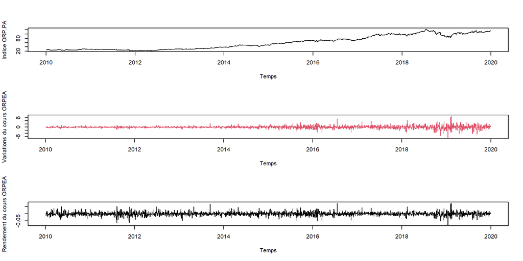

Figure 1.1: Historique de l’action de 2010 à 2020

```r
op <- par(mfrow=c(3,1))
plot(dates, pt, type='l',ylab="Indice ORP.PA" , xlab="Temps")
plot(dates[2:length(dates)],dpt,type='l',col=2, ylab="Variations du cours ORPEA", xlab="Temps") #+ abline(h=0,col=3,lwd=1)
plot(dates[2:length(dates)],rt,type='l',col=1,ylab = "Rendement du cours ORPEA", xlab="Temps")# + abline(h=0,col=3,lwd=0.5)
```

On observe avec le premier chronogramme une tendance haussière dans la valorisation de l’indice sur l’ensemble de la période.  
Le deuxième graphique indique que cette tendance n’est pas constante dans le temps. La variation de la valorisation boursière fluctue autour de 0 sur la période. Il y a une faible fluctation de 2010 à 2015, puis de plus fortes variations jusqu’à la fin de la période en 2020.  
Pour terminer, on peut considérer qu’il y a plusieurs paquets de volatilité. Le premier fin 2011, le second en 2016 et un dernier en 2019. On peut se demander si la valorisation à la hausse comme à la baisse de l’indice se fait brusquement. Sur la période, le rendement logarithmique fluctue autour de 0.

# 2 Tests statistiques

Soit le test de student sur la nullité de la moyenne.

$$\begin{equation}
H_0 : E[rte] = 0 \tag{2.1}
\end{equation}$$
et l’hypothèse alternative,
$$\begin{equation}
H_1 : E[rte] \ne 0 \tag{2.2}
\end{equation}$$

```r
rbar <- mean(rte)
s=sd(rte)
t.test(rte)
```

```
##
##  One Sample t-test
##
## data:  rte
## t = 1.9356, df = 1533, p-value = 0.0531
## alternative hypothesis: true mean is not equal to 0
## 95 percent confidence interval:
##  -8.481424e-06  1.275330e-03
## sample estimates:
##    mean of x
## 0.0006334245
```

La p-value est égale à 0.0531, ce qui est supérieur à 0.05. Nous sommes enclin à ne pas rejeter l’hypothèse nulle. La moyenne de notre série est statistiquement nulle pour un seuil de risque de 5%.

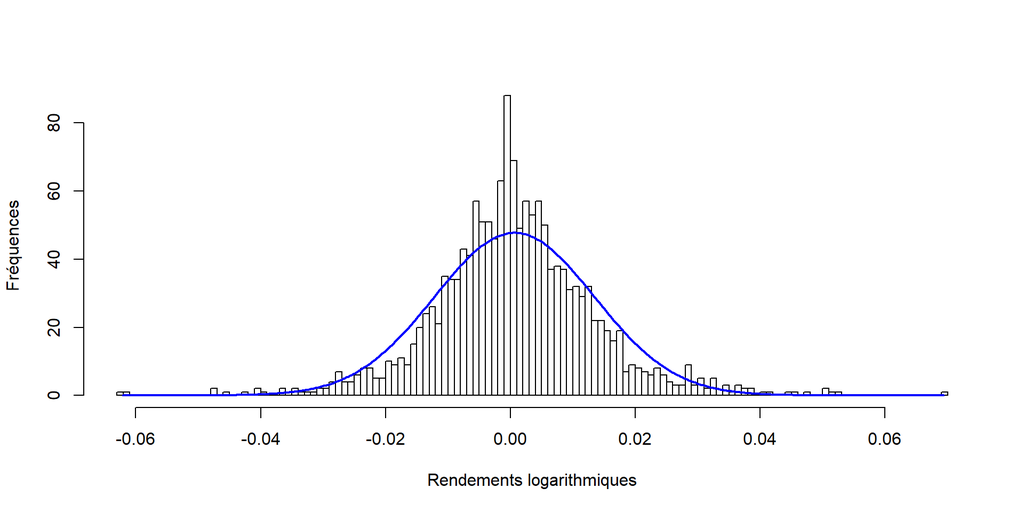

Figure 2.1: Proportion des rendements logarithmiques

```r
plot(h, main= "", xlab="Rendements logarithmiques" , ylab = "Fréquences")
myx <- seq(min(rte), max(rte), length.out= 500)
normal <- dnorm(x = myx, mean =rbar, sd =s)
lines(myx, normal * multiplier[1], col = "blue", lwd = 2)
```

La courbe bleu représente la densité d’une loi normale théorique. L’histogramme représente la fréquence des rendements logarithmiques.  
On distingue une sur-représentation des valeurs extrêmes, comparativement à une loi normale. Visuellement on peut supposer deux choses. Premièrement la distribution semble leptokurtique. Deuxièmement l’occurence de rendements négatifs semble plus probable. Du fait de ce dernier point et que la moyenne soit statistiquement nulle, on peut supposer que les rendements positifs sont plus forts à défaut d’être plus fréquents.  
Nous allons vérifier statistiquement ces deux suppositions.

## 2.1 Test sur la Skewness

On veut étudier si la distribution des rendements logarithmiques est symétrique.

```r
agostino.test(rte)
```

```
##
##  D'Agostino skewness test
##
## data:  rte
## skew = 0.15163, z = 2.42266, p-value = 0.01541
## alternative hypothesis: data have a skewness
```

## 2.2 Test du Kurtosis

Il s’agit ici de vérifier si les queues de distribution sont plus épaisses que pour une loi normale.

```r
anscombe.test(rte)
```

```
##
##  Anscombe-Glynn kurtosis test
##
## data:  rte
## kurt = 5.4912, z = 9.7017, p-value < 2.2e-16
## alternative hypothesis: kurtosis is not equal to 3
```

Le test d’Anscombe se fait sur les moments centrés d’ordre 4 avec la variable suivante : $\mu_4 = E[(X-\mu)^4]$. Soit le test avec comme hypothèse principale
$$\begin{equation}
H_0 : E[\lgroup{X-E(X)\over\sigma_X}\rgroup^4] = 3 \tag{2.5}
\end{equation}$$
et comme alternative
$$\begin{equation}
H_1 : E[({X-E(X)\over\sigma_X})^4] \not= 3 \tag{2.6}
\end{equation}$$
La p-value (< 2.2e-16) est inférieure à 0.05 alors on rejette $H_0$ au seuil de 5%. Le kurtosis de la série vaut 5.4912. Il est supérieur à 3. Notre distribution est en effet leptokurtique. Les valeurs extrêmes sont sur-représentées en comparaison d’une loi normale centrée réduite.

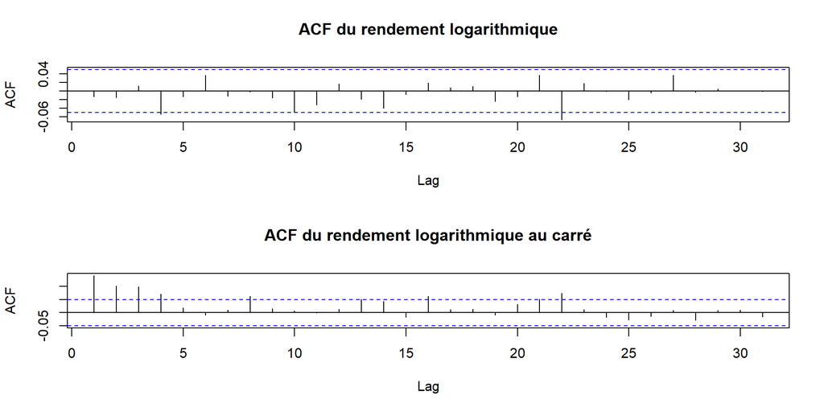

Figure 2.2: Représentation de l’auto-corrélation

```r
op<-par(mfrow=c(2,1))
Acf(rte,main='ACF du rendement logarithmique')
Acf(rte^2,main='ACF du rendement logarithmique au carré')
```

Le premier graphique montre la présence d’autocorrélation des rendements à la période 4, 10 et 22.  
Le second montre la présence d’autocorrélation pour les rendements au carrés jusqu’au 4ème lag, puis elle revient aux lags 8,13,16,21,22.

## 2.3 Test de Ljung-Box

On effectue le test sous les hypothèses suivantes :
$$\begin{equation}
H_0 : \rho(k) =0, \ \forall k=1, ..., K \tag{2.7}
\end{equation}$$
versus
$$\begin{equation}
H_1 : \rho(k) \not= 0 \ pour \ au \ moins \ un \ k \ de \ 1 \ à \ K \tag{2.8}
\end{equation}$$
La statistique du test de Ljung box est la suivante :
$$\begin{equation}
Q_K=N(N+2)\sum_{k=1}^{K} \frac{\hat{\rho}(k)^2}{N-k} \tag{2.9}
\end{equation}$$
Donne sous $H_0$,
$$\begin{equation}
\forall k < K, \ Q_K \to _{N\to\infty}^L \chi^2(K) \tag{2.10}
\end{equation}$$

On effectue le test sur les rendements au carrés.

```r
pvaluesrte =rep(0,25)
pvaluesrte2 =rep(0,25)
for (i in 1:25 ) {
pvaluesrte[i] = Box.test(rte,lag=i,type="Ljung-Box")$p.value
pvaluesrte2[i] = Box.test(rte^2,lag=i,type="Ljung-Box")$p.value
}
pvaluesrte2
```

```
##  [1] 2.968606e-08 7.751033e-11 2.744471e-13 3.286260e-14 1.151301e-13
##  [6] 4.338752e-13 1.457612e-12 2.980949e-13 8.165690e-13 2.407852e-12
## [11] 6.913581e-12 1.687883e-11 7.927659e-12 6.061485e-12 1.251266e-11
## [16] 2.366662e-12 5.233591e-12 1.100031e-11 2.408640e-11 2.850742e-11
## [21] 1.185529e-11 8.522072e-13 1.750711e-12 3.196998e-12 4.312106e-12
```

Toutes les p-values sont inférieures à 0.05 donc on rejette l’hypothèse nulle. Il y a présence d’autocorrélation dans les rendements logarithmiques au carrés.

On effectue à nouveau le test mais sur les rendements.

```r
pvaluesrte
```

```
##  [1] 0.6113373 0.7438269 0.8477922 0.2637273 0.3572574 0.2743503 0.3537398
##  [8] 0.4560044 0.5187186 0.2859266 0.2589044 0.3003635 0.3369837 0.2551317
## [15] 0.3122594 0.3426880 0.4031240 0.4580148 0.4649973 0.5116355 0.4457625
## [22] 0.1699927 0.1924908 0.2338844 0.2529238
```

Toutes les p-values sont supérieures à 0.05. On ne rejette pas l’hypothèse nulle de présence d’autocorrélation. Les rendements logarithmiques ne sont pas auto-corrélés au seuil de 5%, ce qui est ce qu’on veut avoir.

# 3 Saisonnalité

Dans cette partie on se pose la question si le marché intègre des comportements dans la valorisation de l’actif suivant une période spécifique.

## 3.1 Effet Week-end

Nous allons observer dans un premier temps les rendements quotidiens.

```r
jour=format(dates[2:length(dates[1:1534])], format = "%A")
tableaures <- data.frame(matrix(NA,ncol=5,nrow=4))
colnames(tableaures) <- c("lundi","mardi","mercredi","jeudi","vendredi")
rownames(tableaures) <- c("moyenne en %","écart-type annuel en %","skewness","kurtosis")
rtemar<-as.numeric(rte[jour=="mardi"])
mardi<-mean(rtemar) #moyenne journaliere
tableaures[1,2] <- mardi*100 #moyenne journaliere en %
tableaures[2,2] <- sd(rtemar)*100*sqrt(252) #ecart-type annualise en %
tableaures[3,2] <- skewness(rtemar)
tableaures[4,2] <- kurtosis(rtemar)
rtemer<-as.numeric(rte[jour=="mercredi"])
mer<-mean(rtemer)
tableaures[1,3] <- mer*100
tableaures[2,3] <- sd(rtemer)*100*sqrt(252)
tableaures[3,3] <- skewness(rtemer)
tableaures[4,3] <- kurtosis(rtemer)
rtejeu<-as.numeric(rte[jour=="jeudi"])
jeudi<-mean(rtejeu)
tableaures[1,4] <- jeudi*100
tableaures[2,4] <- sd(rtejeu)*100*sqrt(252)
tableaures[3,4] <- skewness(rtejeu)
tableaures[4,4] <- kurtosis(rtejeu)
rteven<-as.numeric(rte[jour=="vendredi"])
ven<-mean(rteven)
tableaures[1,5] <- ven*100
tableaures[2,5] <- sd(rteven)*100*sqrt(252)
tableaures[3,5] <- skewness(rteven)
tableaures[4,5] <- kurtosis(rteven)
rtelun<-as.numeric(rte[jour=="lundi"])
lundi<-mean(rtelun)
tableaures[1,1] <- lundi*100
tableaures[2,1] <- sd(rtelun)*100*sqrt(252)
tableaures[3,1] <- skewness(rtelun)
tableaures[4,1] <- kurtosis(rtelun)
tableaures
```

```
##                             lundi      mardi   mercredi      jeudi    vendredi
## moyenne en %            0.1169539 -0.0145240  0.1753402  0.0500840 -0.01215033
## écart-type annuel en % 20.8156524 21.8327837 20.2206318 19.8165619 18.85284953
## skewness               -0.4194101  0.2556677  0.8499496  0.1096861 -0.07523499
## kurtosis                3.2251557  1.6665101  3.5413287  0.9169332  2.75553934
```

La moyenne du lundi varie de 0.11695% en moyenne. Ce jour est constitué plus fréquemment de rendements positifs (coefficient de skewness < 0). La distribution des rendements moyens a une queue plus épaisse qu’une loi normale (kurtosis > 3). Il y a une sur-représentation des valeurs extrêmes. Comme en moyenne les rendements sont positifs et qu’il y a majoritairement des rendements positifs. Les rendements négatifs lorsqu’ils occurent ne sont pas spécialement extrêmes.  
On constate ce même effet le mercredi avec une moyenne de 0.17534% et un kurtosis > 3 mais avec un skewness positif donc fréquence plus haute de rendements négatifs. Le lundi et mercredi sont les jours où la moyenne des rendements est la plus haute.  
Le mardi est le jour où l’écart type est le plus élevé. Ce point vient contredire French et Roll et Baillie et Bollerslev sur les effets “Lundi” ou “Mercredi”. C’est même l’inverse de l’effet Mercredi puisqu’à partir de mardi l’écart type diminue plus on s’approche du week end. Là où eux prédisent un accroissement. Il y a majoritairement plus de rendements négatifs (coefficient de skewness > 0) et la distribution des rendements est plus aplatie qu’une loi normale (coefficient de kurtosis < 3). Les jeudi et vendredi sont notables par un kurtosis tout deux inférieur à 3. La distribution des rendements est comme pour mardi plus aplanie qu’une loi normale. Leur moyenne respective est tout comme mardi là aussi proche de 0. En revanche, le jeudi est composé de plus de rendement négatifs que positifs, le vendredi c’est l’inverse. Respectivement, coefficient de skewness positif et négatif.

## 3.2 Effet janvier

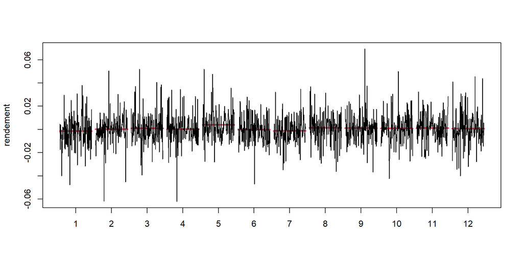

Figure 3.1: Volatilité des rendements selon les mois de l’année

```r
monthplot(rte, ylab="rendement",main="", cex.main=1,col.base=2,lwd.base=3)
```

Ce graphique permet d’observer deux composantes pour juger de la volatilité, l’ampleur et la durée.  
On a un double pic de rendements négatifs, le premier en février et le second en avril, pour une valeur de -0.06%. Le pic positif est atteint en septembre à environ 0.07%. On peut voir que le pic très bas de février est suivi d’un pic fortement positif (+0.05%) quelques jours plus tard. Les traits rouges représentent la moyenne mensuelle. On voit que le plus haut est en mai et le plus bas semble être en juillet. Acheter fin avril et vendre fin mai offre en moyenne un rendement positif. Le rendement moyen décroît de mai à juillet. Dans cette optique, il semble en moyenne rentable de vendre fin mai pour racheter fin juillet car en général le rendement moyen à diminué sur cette période de 2 mois.

# 4 Stationnarité

## 4.1 Test de Dicky-Fuller

J’ai testé deux premiers modèles avec une tendance et une constante. Je ne montre volontairement pas les processus et les résultats afin de ne pas surcharger inutilement, l’enjeu n’est pas dans ces tests.

Le test se fera sous les hypothèses suivantes :
$$\begin{equation}
H_0 : \rho - 1 = 0 \ versus \ H_a : \rho < 1 \tag{4.1}
\end{equation}$$
Soit le modèle :
$$\begin{equation}
\Delta rte_t = (\rho-1)rte_{t-1} + \epsilon_t \tag{4.2}
\end{equation}$$

```r
summary(ur.df(rte,type='none',lags=0))
```

```
##
## ###############################################
## # Augmented Dickey-Fuller Test Unit Root Test #
## ###############################################
##
## Test regression none
##
##
## Call:
## lm(formula = z.diff ~ z.lag.1 - 1)
##
## Residuals:
##       Min        1Q    Median        3Q       Max
## -0.062341 -0.006521  0.000206  0.007498  0.069444
##
## Coefficients:
##         Estimate Std. Error t value Pr(>|t|)
## z.lag.1 -1.01047    0.02557  -39.51   <2e-16 ***
## ---
## Signif. codes:  0 '***' 0.001 '**' 0.01 '*' 0.05 '.' 0.1 ' ' 1
##
## Residual standard error: 0.01284 on 1532 degrees of freedom
## Multiple R-squared:  0.5047, Adjusted R-squared:  0.5044
## F-statistic:  1561 on 1 and 1532 DF,  p-value: < 2.2e-16
##
##
## Value of test-statistic is: -39.5137
##
## Critical values for test statistics:
##       1pct  5pct 10pct
## tau1 -2.58 -1.95 -1.62
```

On utilise un modèle de type “none” après avoir réfuté les modèles “trend” et “drift” car respectivement le coefficient associé à $\beta_1$ et $\beta_0$ n’est pas significatif. Conclusion tirée de la p-value supérieure à 0.05. Le processus ne pourra pas être TS. De surcroît, le t calculé vaut -39.5137. Or -39.5137 < -1.95 ($\tau_1$) donc on rejette H0, ce qui implique que le PGD n’est pas DS. On en conclut que le PGD est stationnaire. Cette conclusion n’est valide que si les aléas de la régression ne sont pas auto-corrélés.

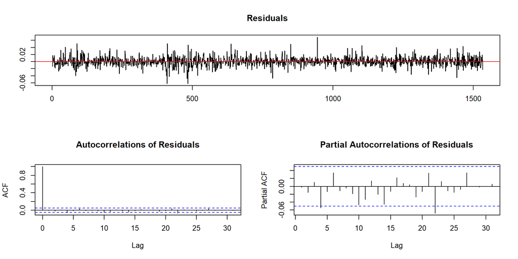

Figure 4.1: Graphiques des résidus du test de Dickey-Fuller

```r
plot(ur.df(rte,lag=0,type='none'))
```

Dans le graphique de la PACF on constate que les aléas sont corrélés aux périodes 4 et 22, expliqué par le dépassement de la ligne bleue en pointillée. La conclusion tirée n’est pas valide. On va utiliser le test Dickey Fuller Augmenté, c’est à dire le même test en injectant des lags.

## 4.2 Dickey-Fuller Augmenté

Le modèle utilisé n’est plus ‘none’ mais ‘drift’. En effet, dans le test de DF nous avons rejeté le modèle drift suite à une p-value = 0.0515 (résultat volontairement non montré pour ne pas surcharger). Or, en incrémentant des lags le coefficient associé à $\beta_0$ est significatif (voir sortie R du test ADF qui suit) donc on utilisera le type ‘drift’ dorénavant. L’equation générale dans notre cas est la suivante :

$$\begin{equation}
\Delta rte_t = (\rho -1)rte_{t-1} + \beta_0 + \sum_{j=1}^{k} \gamma_j \Delta rte_{t-j} + \epsilon_t \tag{4.3}
\end{equation}$$
Sous les hypothèses :
$$\begin{equation}
H_0 : \rho-1 = 0 \ versus \ H_a : \rho < 1 \tag{4.4}
\end{equation}$$
Notre règle de décision dans la retenue du nombre de lags significatifs sera de garder gamma si la t-value associée, en valeur absolue, est supérieure à 1.6.

### 4.2.1 Critère MAIC

Il nous faut définir en amont le critère de décision du nombre de lags retenus. Calculé suivant la formule de Schwert.

```r
schwert <- as.integer(12*(length(rte)/100)^0.25)
summary(CADFtest(rte,criterion="MAIC",type="drift",max.lag.y=schwert))
```

```
## Augmented DF test
##                                                 ADF test
## t-test statistic:                          -3.935979e+01
## p-value:                                    9.718696e-14
## Max lag of the diff. dependent variable:    0.000000e+00
##
## Call:
## dynlm(formula = formula(model), start = obs.1, end = obs.T)
##
## Residuals:
##       Min        1Q    Median        3Q       Max
## -0.063079 -0.007196 -0.000454  0.006838  0.068782
##
## Coefficients:
##               Estimate Std. Error t value Pr(>|t|)
## (Intercept)  0.0006759  0.0003311   2.042   0.0414 *
## L(y, 1)     -1.0130415  0.0257380 -39.360 9.72e-14 ***
## ---
## Signif. codes:  0 '***' 0.001 '**' 0.01 '*' 0.05 '.' 0.1 ' ' 1
##
## Residual standard error: 0.01285 on 1508 degrees of freedom
## Multiple R-squared:  0.5067, Adjusted R-squared:  0.5064
## F-statistic:    NA on NA and NA DF,  p-value: NA
```

D’après le MAIC on retient un modèle avec aucun lag significatif. On a rejeté ce modèle auparavant. On utlisera par conséquent un autre critère.

### 4.2.2 Critère BIC

```r
summary(ur.df(rte,type='drift',selectlags = "BIC",lags=schwert))
```

```
##
## ###############################################
## # Augmented Dickey-Fuller Test Unit Root Test #
## ###############################################
##
## Test regression drift
##
##
## Call:
## lm(formula = z.diff ~ z.lag.1 + 1 + z.diff.lag)
##
## Residuals:
##       Min        1Q    Median        3Q       Max
## -0.063614 -0.007147 -0.000364  0.006789  0.068649
##
## Coefficients:
##               Estimate Std. Error t value Pr(>|t|)
## (Intercept)  0.0006879  0.0003316   2.075   0.0382 *
## z.lag.1     -1.0311559  0.0366423 -28.141   <2e-16 ***
## z.diff.lag   0.0178844  0.0257454   0.695   0.4874
## ---
## Signif. codes:  0 '***' 0.001 '**' 0.01 '*' 0.05 '.' 0.1 ' ' 1
##
## Residual standard error: 0.01285 on 1507 degrees of freedom
## Multiple R-squared:  0.5069, Adjusted R-squared:  0.5062
## F-statistic: 774.6 on 2 and 1507 DF,  p-value: < 2.2e-16
##
##
## Value of test-statistic is: -28.1411 395.9613
##
## Critical values for test statistics:
##       1pct  5pct 10pct
## tau2 -3.43 -2.86 -2.57
## phi1  6.43  4.59  3.78
```

### 4.2.3 Critère Schwert

```r
summary(ur.df(rte,type='drift',lags=schwert-2))
```

```
##
## ###############################################
## # Augmented Dickey-Fuller Test Unit Root Test #
## ###############################################
##
## Test regression drift
##
##
## Call:
## lm(formula = z.diff ~ z.lag.1 + 1 + z.diff.lag)
##
## Residuals:
##       Min        1Q    Median        3Q       Max
## -0.063439 -0.006844 -0.000330  0.006716  0.066641
##
## Coefficients:
##                Estimate Std. Error t value Pr(>|t|)
## (Intercept)   0.0008388  0.0003412   2.458  0.01408 *
## z.lag.1      -1.2939868  0.1372178  -9.430  < 2e-16 ***
## z.diff.lag1   0.2804015  0.1336959   2.097  0.03613 *
## z.diff.lag2   0.2658780  0.1298548   2.048  0.04078 *
## z.diff.lag3   0.2727357  0.1259802   2.165  0.03055 *
## z.diff.lag4   0.2156845  0.1221846   1.765  0.07773 .
## z.diff.lag5   0.1971725  0.1181861   1.668  0.09546 .
## z.diff.lag6   0.2297112  0.1139618   2.016  0.04401 *
## z.diff.lag7   0.2208780  0.1094257   2.019  0.04372 *
## z.diff.lag8   0.2158536  0.1048041   2.060  0.03961 *
## z.diff.lag9   0.1939194  0.1003134   1.933  0.05341 .
## z.diff.lag10  0.1443458  0.0957754   1.507  0.13199
## z.diff.lag11  0.1110315  0.0908326   1.222  0.22176
## z.diff.lag12  0.1221371  0.0859121   1.422  0.15534
## z.diff.lag13  0.1024292  0.0811177   1.263  0.20689
## z.diff.lag14  0.0580674  0.0762555   0.761  0.44649
## z.diff.lag15  0.0413384  0.0710842   0.582  0.56096
## z.diff.lag16  0.0663591  0.0656353   1.011  0.31217
## z.diff.lag17  0.0748806  0.0593416   1.262  0.20720
## z.diff.lag18  0.0752017  0.0525182   1.432  0.15238
## z.diff.lag19  0.0492987  0.0454869   1.084  0.27863
## z.diff.lag20  0.0345870  0.0369297   0.937  0.34914
## z.diff.lag21  0.0686789  0.0259656   2.645  0.00826 **
## ---
## Signif. codes:  0 '***' 0.001 '**' 0.01 '*' 0.05 '.' 0.1 ' ' 1
##
## Residual standard error: 0.01283 on 1489 degrees of freedom
## Multiple R-squared:  0.5153, Adjusted R-squared:  0.5082
## F-statistic: 71.97 on 22 and 1489 DF,  p-value: < 2.2e-16
##
##
## Value of test-statistic is: -9.4302 44.4654
##
## Critical values for test statistics:
##       1pct  5pct 10pct
## tau2 -3.43 -2.86 -2.57
## phi1  6.43  4.59  3.78
```

## 4.3 Zivot et Andrews

Dans le cas avec un choc structurel et un choc conjoncturel on teste le modèle suivant :
$$\begin{equation}
rte_{t} = \beta_{0} + \beta_{1}t + \rho rte_{t-1} + \delta_{1}DU_{t}(\kappa) + \delta_{2}DT_{t}(\kappa) + \sum_{j=1}^{p} \gamma_{j}\Delta rte_{t-j} + \epsilon_{t} \tag{4.6}
\end{equation}$$
Sous
$$\begin{equation}
H_{0} : 1 \ racine \ unitaire \ sans \ changement\ structurel\ exogène \tag{4.7}
\end{equation}$$
Contre
$$\begin{equation}
H_{a} : TS \ avec \ changement \ structurel \ à \ une \ date \ endogène \tag{4.8}
\end{equation}$$

```r
summary(ur.za(rte, model='intercept', lag = schwert-2))
```

```
##
## ################################
## # Zivot-Andrews Unit Root Test #
## ################################
##
##
## Call:
## lm(formula = testmat)
##
## Residuals:
##       Min        1Q    Median        3Q       Max
## -0.062727 -0.006814 -0.000398  0.006854  0.065441
##
## Coefficients:
##               Estimate Std. Error t value Pr(>|t|)
## (Intercept)  8.556e-05  6.907e-04   0.124  0.90143
## y.l1        -4.431e-01  1.442e-01  -3.072  0.00216 **
## trend       -1.574e-06  1.412e-06  -1.115  0.26516
## y.dl1        4.227e-01  1.403e-01   3.014  0.00262 **
## y.dl2        4.012e-01  1.360e-01   2.951  0.00322 **
## y.dl3        4.012e-01  1.316e-01   3.047  0.00235 **
## y.dl4        3.374e-01  1.274e-01   2.648  0.00818 **
## y.dl5        3.119e-01  1.230e-01   2.536  0.01132 *
## y.dl6        3.372e-01  1.183e-01   2.849  0.00444 **
## y.dl7        3.211e-01  1.134e-01   2.832  0.00468 **
## y.dl8        3.089e-01  1.083e-01   2.851  0.00442 **
## y.dl9        2.802e-01  1.035e-01   2.708  0.00685 **
## y.dl10       2.240e-01  9.859e-02   2.272  0.02323 *
## y.dl11       1.834e-01  9.327e-02   1.967  0.04939 *
## y.dl12       1.876e-01  8.800e-02   2.132  0.03316 *
## y.dl13       1.614e-01  8.289e-02   1.947  0.05175 .
## y.dl14       1.105e-01  7.773e-02   1.422  0.15528
## y.dl15       8.705e-02  7.226e-02   1.205  0.22849
## y.dl16       1.054e-01  6.654e-02   1.584  0.11338
## y.dl17       1.071e-01  5.999e-02   1.785  0.07443 .
## y.dl18       1.006e-01  5.294e-02   1.899  0.05770 .
## y.dl19       6.821e-02  4.573e-02   1.492  0.13601
## y.dl20       4.699e-02  3.702e-02   1.269  0.20451
## y.dl21       7.461e-02  2.596e-02   2.875  0.00410 **
## du           3.397e-03  1.296e-03   2.621  0.00886 **
## ---
## Signif. codes:  0 '***' 0.001 '**' 0.01 '*' 0.05 '.' 0.1 ' ' 1
##
## Residual standard error: 0.01279 on 1487 degrees of freedom
##   (22 observations deleted due to missingness)
## Multiple R-squared:  0.02576,    Adjusted R-squared:  0.01003
## F-statistic: 1.638 on 24 and 1487 DF,  p-value: 0.02674
##
##
## Teststatistic: -10.0052
## Critical values: 0.01= -5.34 0.05= -4.8 0.1= -4.58
##
## Potential break point at position: 611
```

Dans une optique de ne pas surcharger inutilement le pdf j’ai testé sans laisser les résultats “model=‘both’ et model=‘trend’”. Ceux-ci n’étant pas concluants, j’ai procédé à l’eviction d’un potentiel choc structurel dans l’intercept. On retient ainsi un modèle avec un choc conjoncturel dans la tendance, représenté par “du”.  
Le dernier coefficient associé à un lag significatif est à la position 21, une nouvelle fois. Nous retenons ce modèle avec les coefficients associés aux lags 1 à 13, 17, 18 et 21 comme significatifs car leurs t-values sont supérieures en valeur absolue à 1,6.  
Le tau calculé vaut -10.0052, le tau simulé pour un risque de 5% est -4.8. Comme -10.0052 < -4.8 nous n’acceptons pas $H_0$ la présence de racine unitaire sans changement structurel. Le choc potentiel intervient à la position 611, c’est à dire le 18 Mai 2012. Si l’on se rapporte à la figure (1.1) on peut voir une légère remontée de l’indice du prix, concernant les rendements on ne distingue pas volatilité spécialement forte. Je reviendrai sur ce point en illustrant avec le graphique de la statistique du test pour toutes les périodes.  
Le dernier point à mentionner est la non significativité du coefficent associé à $\beta_1$. Défini dans la ligne “trend”, sa p-value (0.26516) est supérieure au seuil de significativité de 5%. Le processus ne semble pas TS, nous sommes enclin à rejeter l’hypothèse alternative.

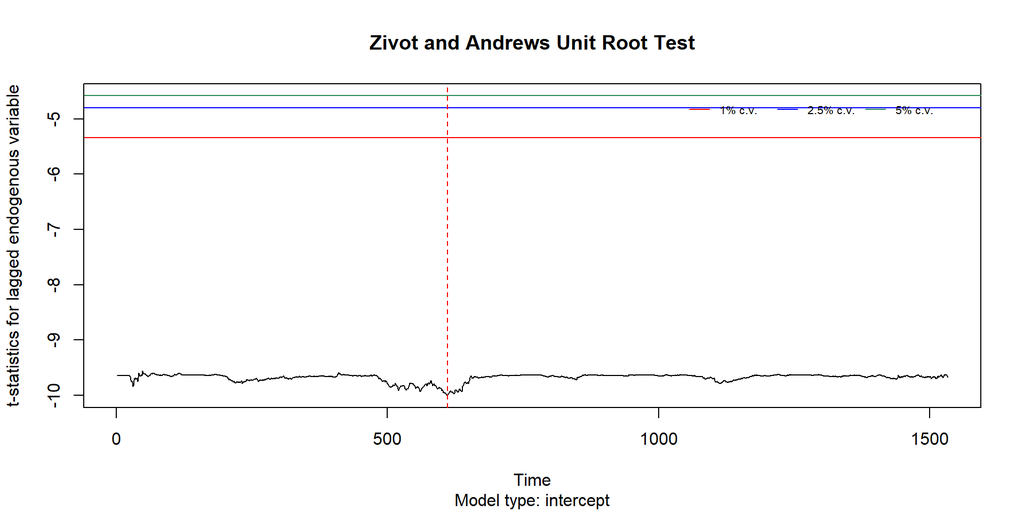

Figure 4.2: Valeurs de la statistique de Zivot et Andrews à chaque période

```r
plot(ur.za(rte,model='intercept',lag=schwert-2))
```

## 4.4 Lee et Strazicich

Avec
$$\begin{equation}
H_{0} : 1 \ racine \ unitaire \ avec \ changement \ structurel \ à \ 1 \ date \ possible. \tag{4.10}
\end{equation}$$
Contre
$$\begin{equation}
H_{a} : \ TS \ avec \ changement \ structurel \tag{4.11}
\end{equation}$$

```r
ur.ls(rte, model = "crash",breaks=1, lags=schwert-1, method = "GTOS", pn=0.1,print.results = "print")
```

```
## [1] -3.643024
## [1] "First possible structural break at position: 155"
## [1] "The location of the first break - lambda_1: 0.1 , with the number of total observations: 1534"
## Critical values - Crash model:
##          1%     5%    10%
## [1,] -4.239 -3.566 -3.211
## [1] "Number of lags determined by general-to-specific lag selection: 22"
## Runtime:
## Time difference of 0.216547 mins
```

```
## [[1]]
## [[1]]$`t-stat`
## [1] -3.643024
##
## [[1]]$`First break`
## [1] 155
##
## [[1]]$Runtime
## Time difference of 0.216547 mins
##
##
## [[2]]
##
## Call:
## lm(formula = y.diff ~ 0 + lagmatrix(S.tilde, 1)[, -1] + datmat[,
##     2:(slag + 2)] + Dt.diff)
##
## Residuals:
##       Min        1Q    Median        3Q       Max
## -0.057524 -0.007816 -0.000463  0.007335  0.067828
##
## Coefficients: (1 not defined because of singularities)
##                                          Estimate Std. Error t value Pr(>|t|)
## lagmatrix(S.tilde, 1)[, -1]            -0.1568042  0.0430423  -3.643 0.000279
## datmat[, 2:(slag + 2)]NoLags                   NA         NA      NA       NA
## datmat[, 2:(slag + 2)]S.tilde.diff.l1  -0.7984067  0.0480380 -16.620  < 2e-16
## datmat[, 2:(slag + 2)]S.tilde.diff.l2  -0.7576197  0.0521853 -14.518  < 2e-16
## datmat[, 2:(slag + 2)]S.tilde.diff.l3  -0.6952845  0.0554108 -12.548  < 2e-16
## datmat[, 2:(slag + 2)]S.tilde.diff.l4  -0.7003360  0.0578977 -12.096  < 2e-16
## datmat[, 2:(slag + 2)]S.tilde.diff.l5  -0.6661311  0.0603248 -11.042  < 2e-16
## datmat[, 2:(slag + 2)]S.tilde.diff.l6  -0.5805412  0.0622725  -9.323  < 2e-16
## datmat[, 2:(slag + 2)]S.tilde.diff.l7  -0.5376275  0.0634382  -8.475  < 2e-16
## datmat[, 2:(slag + 2)]S.tilde.diff.l8  -0.4895440  0.0640098  -7.648 3.65e-14
## datmat[, 2:(slag + 2)]S.tilde.diff.l9  -0.4602540  0.0642062  -7.168 1.19e-12
## datmat[, 2:(slag + 2)]S.tilde.diff.l10 -0.4605647  0.0642124  -7.173 1.16e-12
## datmat[, 2:(slag + 2)]S.tilde.diff.l11 -0.4427680  0.0640957  -6.908 7.27e-12
## datmat[, 2:(slag + 2)]S.tilde.diff.l12 -0.3798736  0.0635220  -5.980 2.79e-09
## datmat[, 2:(slag + 2)]S.tilde.diff.l13 -0.3496999  0.0625574  -5.590 2.70e-08
## datmat[, 2:(slag + 2)]S.tilde.diff.l14 -0.3469592  0.0613911  -5.652 1.90e-08
## datmat[, 2:(slag + 2)]S.tilde.diff.l15 -0.3160724  0.0600229  -5.266 1.60e-07
```

[output cut: 28 more lines]

```
## datmat[, 2:(slag + 2)]S.tilde.diff.l17 ***
## datmat[, 2:(slag + 2)]S.tilde.diff.l18 **
## datmat[, 2:(slag + 2)]S.tilde.diff.l19 **
## datmat[, 2:(slag + 2)]S.tilde.diff.l20 *
## datmat[, 2:(slag + 2)]S.tilde.diff.l21
## datmat[, 2:(slag + 2)]S.tilde.diff.l22 *
## Dt.diff1                               ***
## Dt.diff2                               .
## ---
## Signif. codes:  0 '***' 0.001 '**' 0.01 '*' 0.05 '.' 0.1 ' ' 1
##
## Residual standard error: 0.0132 on 1486 degrees of freedom
##   (23 observations deleted due to missingness)
## Multiple R-squared:  0.4878, Adjusted R-squared:  0.4792
## F-statistic: 56.61 on 25 and 1486 DF,  p-value: < 2.2e-16
```

Le dernier coefficient associé à un lag significatif est en position 22. En sélectionnant les t-values supérieures à 1.6 en valeur absolue tous les coefficients associés aux lags sont significatifs sauf le 21eme. Le tau calculé vaut -3.643 et le tau simulé vaut -3.566. -3.643 < -3.566, alors on rejette l’hypothèse nulle de présence de racine unitaire sans changement structurel. Choc potentiel en position 155, le 9 août 2010.

On va procéder au même test de LS mais en autorisant 2 chocs dans notre série.

```r
ur.ls(rte, model = "crash", breaks=2, lags=schwert-1, method = "GTOS", pn=0.1,print.results = "print")
```

```
## [1] -4.45154
## [1] "First possible structural break at position: 171"
## [1] "The location of the first break - lambda_1: 0.1 , with the number of total observations: 1534"
## [1] "Second possible structural break at position: 206"
## [1] "The location of the second break - lambda_2: 0.1 , with the number of total observations: 1534"
## Critical values:
##               Break 2 - 0.4 - 1% Break 2 - 0.4 - 5% Break 2 - 0.4 - 10%
## Break 1 - 0.2              -6.16              -5.59               -5.27
## Break 1 - 0.4                 NA                 NA                  NA
## Break 1 - 0.6                 NA                 NA                  NA
##               Break 2 - 0.6 - 1% Break 2 - 0.6 - 5% Break 2 - 0.6 - 10%
## Break 1 - 0.2              -6.41              -5.74               -5.32
## Break 1 - 0.4              -6.45              -5.67               -5.31
## Break 1 - 0.6                 NA                 NA                  NA
##               Break 2 - 0.8 - 1% Break 2 - 0.8 - 5% Break 2 - 0.8 - 10%
## Break 1 - 0.2              -6.33              -5.71               -5.33
## Break 1 - 0.4              -6.42              -5.65               -5.32
## Break 1 - 0.6              -6.32              -5.73               -5.32
## [1] "Number of lags determined by general-to-specific lag selection: 21"
## Runtime:
## Time difference of 154.1195 mins
```

```
## [[1]]
## [[1]]$`t-stat`
## [1] -4.45154
##
## [[1]]$`First break`
## [1] 171
##
## [[1]]$`Second break`
## [1] 206
##
## [[1]]$Runtime
## Time difference of 154.1195 mins
##
##
## [[2]]
##
## Call:
## lm(formula = y.diff ~ 0 + lagmatrix(S.tilde, 1)[, -1] + datmat[,
##     2:(slag + 2)] + Dt.diff)
##
## Residuals:
##       Min        1Q    Median        3Q       Max
## -0.050479 -0.007713 -0.000274  0.007333  0.070374
##
## Coefficients: (1 not defined because of singularities)
##                                          Estimate Std. Error t value Pr(>|t|)
## lagmatrix(S.tilde, 1)[, -1]            -0.1630466  0.0366270  -4.452 9.16e-06
## datmat[, 2:(slag + 2)]NoLags                   NA         NA      NA       NA
## datmat[, 2:(slag + 2)]S.tilde.diff.l1  -0.7139205  0.0425395 -16.783  < 2e-16
## datmat[, 2:(slag + 2)]S.tilde.diff.l2  -0.6077571  0.0460409 -13.200  < 2e-16
## datmat[, 2:(slag + 2)]S.tilde.diff.l3  -0.4977999  0.0484110 -10.283  < 2e-16
## datmat[, 2:(slag + 2)]S.tilde.diff.l4  -0.4654228  0.0499225  -9.323  < 2e-16
## datmat[, 2:(slag + 2)]S.tilde.diff.l5  -0.3984556  0.0512138  -7.780 1.35e-14
## datmat[, 2:(slag + 2)]S.tilde.diff.l6  -0.2869837  0.0520133  -5.518 4.05e-08
## datmat[, 2:(slag + 2)]S.tilde.diff.l7  -0.2325012  0.0522024  -4.454 9.07e-06
## datmat[, 2:(slag + 2)]S.tilde.diff.l8  -0.1824565  0.0521942  -3.496 0.000487
## datmat[, 2:(slag + 2)]S.tilde.diff.l9  -0.1568659  0.0520558  -3.013 0.002627
## datmat[, 2:(slag + 2)]S.tilde.diff.l10 -0.1672863  0.0518188  -3.228 0.001272
## datmat[, 2:(slag + 2)]S.tilde.diff.l11 -0.1599294  0.0514145  -3.111 0.001903
## datmat[, 2:(slag + 2)]S.tilde.diff.l12 -0.1062472  0.0509905  -2.084 0.037361
```

[output cut: 31 more lines]

```
## datmat[, 2:(slag + 2)]S.tilde.diff.l17
## datmat[, 2:(slag + 2)]S.tilde.diff.l18
## datmat[, 2:(slag + 2)]S.tilde.diff.l19
## datmat[, 2:(slag + 2)]S.tilde.diff.l20
## datmat[, 2:(slag + 2)]S.tilde.diff.l21 *
## Dt.diff1                               ***
## Dt.diff2                               *
## Dt.diff3                               **
## ---
## Signif. codes:  0 '***' 0.001 '**' 0.01 '*' 0.05 '.' 0.1 ' ' 1
##
## Residual standard error: 0.01369 on 1487 degrees of freedom
##   (22 observations deleted due to missingness)
## Multiple R-squared:  0.449,  Adjusted R-squared:  0.4397
## F-statistic: 48.46 on 25 and 1487 DF,  p-value: < 2.2e-16
```

Nous retenons ce modèle avec le coefficient associé au 21ème lag significatif. Dans cette spécification, les coefficients associés aux lags 1 à 14 et 21 sont significatifs d’après leurs t-values respectives supérieures en valeur absolue à 1,6. La statistique calculée du test vaut -4,45. Elle est à comparer avec la statistique tabulée pour un risque de 5% de -5,59. Comme notre statistique calculée est supérieure à la statistique tabulée, nous sommes enclin à ne pas rejeter l’hypothèse nulle de présence de racine unitaire avec changements structurels aux dates 171 et 206, soit le 31 août 2010 et le 19 octobre 2010. On retrouve une proximité entre les deux dates mais aussi une proximité avec celle établie au test précédant n’autorisant qu’un seul choc. Nos deux tests LS montrent une cohérence dans la localisation d’un potentiel choc structurel vers le 3ème trimestre de 2010. Dans un soucis de précaution, je préfère me baser sur les résultat du test avec un seul choc. Les 2 chocs étant très proche pour l’amplitude de la série, j’ai peur que celà biaise la valeur de la statistique calculée et donc le résultat sur la stationnarité.

On conclut à la stationnarité de notre série.
$$\begin{equation}
rte \sim I(0) \tag{4.12}
\end{equation}$$

# 5 Modèle économétrique

Afin de ne pas contrarier la théorie, on intègre le graphique de l’eacf bien que son utilité me reste incomprise au vu de la complexité des données réelles…

```r
eacf(rte)
```

```
## AR/MA
##   0 1 2 3 4 5 6 7 8 9 10 11 12 13
## 0 o o o x o o o o o o o  o  o  o
## 1 x o o x o o o o o o o  o  o  o
## 2 x x o o o o o o o o o  o  o  o
## 3 x x x o o o o o o o o  o  o  o
## 4 x x x x o o o o o o o  o  o  o
## 5 x x x x x o o o o o o  o  o  o
## 6 x x x o x x o o o o o  o  o  o
## 7 x x o x o x x o o o o  o  o  o
```

## 5.1 Choix du potentiel PGD

```r
reg <- stats::arima(rte, order = c(4,0,4), fixed= c(NA,0,NA,NA,NA,0,NA,NA,NA), transform.pars = FALSE)
coeftest(reg)
```

```
##
## z test of coefficients:
##
##              Estimate  Std. Error z value  Pr(>|z|)
## ar1        0.34951092  0.08870313  3.9402 8.140e-05 ***
## ar3       -0.44898586  0.09332732 -4.8109 1.503e-06 ***
## ar4        0.79171326  0.09769626  8.1038 5.326e-16 ***
## ma1       -0.36751117  0.07933028 -4.6327 3.610e-06 ***
## ma3        0.45636305  0.08428540  5.4145 6.146e-08 ***
## ma4       -0.84522474  0.08652078 -9.7690 < 2.2e-16 ***
## intercept  0.00062969  0.00025969  2.4248   0.01532 *
## ---
## Signif. codes:  0 '***' 0.001 '**' 0.01 '*' 0.05 '.' 0.1 ' ' 1
```

Les coefficients associés sont significatifs au seuil de 5% avec leurs p-values inférieures à 0.05.
La valeur estimée de la moyenne est très proche de l’espérance que nous avons calculé avec rbar.
$$\begin{equation}
rte_t= 0.00062969 + 0.34951092rte_{t-1} - 0.44898586rte_{t-3} + 0.79171326rte_{t-4} -0.36751117\epsilon_{t-1} \\ + 0.45636305\epsilon_{t-3} -0.84522474\epsilon_{t-4} \tag{5.1}
\end{equation}$$

## 5.2 Vérification des aléas

### 5.2.1 Espérance des aléas

On réalise le test d’espérance nulle des aléas de la régression définie avant. Soit l’hypothèse nulle :
$$\begin{equation}
H_0 : E[\epsilon] = 0 \tag{5.2}
\end{equation}$$
contre l’hypothèse alternative :
$$\begin{equation}
H_a : E[\epsilon] \not= 0 \tag{5.3}
\end{equation}$$

```r
residu <- reg$res
t.test(residu)
```

```
##
##  One Sample t-test
##
## data:  residu
## t = 0.018993, df = 1533, p-value = 0.9848
## alternative hypothesis: true mean is not equal to 0
## 95 percent confidence interval:
##  -0.0006331501  0.0006455316
## sample estimates:
##    mean of x
## 6.190705e-06
```

La p-value est supérieure à 5%. L’espérance conditionnelle des résidus est nulle.

### 5.2.2 Test d’autocorrélation

On vérifie si les aléas ne sont pas autocorrélés.

```r
residuv=(residu-mean(residu))/sd(residu)
K <- 22
tmp<-rep(0,K)

for(i in 1:K){
tmp[i]<-Box.test(residuv,lag=i,type="Ljung-Box")$p.value
}
tmp
```

```
##  [1] 0.8748542 0.9162119 0.9659461 0.9605668 0.9766062 0.6462438 0.6233030
##  [8] 0.7067786 0.7912843 0.7724056 0.6195002 0.6733380 0.7206651 0.7577597
## [15] 0.8113955 0.8398447 0.8817430 0.8748888 0.8931140 0.9173887 0.9171870
## [22] 0.6879482
```

Toutes les p-values sont supérieures à 0.05. Il n’y a pas d’autocorrélation des résidus.

# 6 Clusters de volatilité

On vérifie pour finir l’hypothèse d’homoscédasticité conditionnelles des résidus. Si oui, nous pourrons dire que les résidus sont des bruits blancs.

$$\begin{equation}
H_0 : \alpha_1 = \alpha_2 = ... = \alpha_m = 0 \tag{6.1}
\end{equation}$$
$$\begin{equation}
H_1 : au\ moins\ un \ \alpha_i \not= 0 \ ,\ avec\ i \not= 0 \tag{6.2}
\end{equation}$$

```r
LM <- rep(0,22)
for (i in 1:22){
  LM[[i]] = ArchTest(as.numeric(rte),lags=i)$p.value
}
LM
```

```
##  [1] 3.055613e-08 1.230270e-09 9.676250e-11 1.280220e-10 4.711928e-10
##  [6] 1.008187e-09 3.249305e-09 7.148425e-10 1.960756e-09 5.291530e-09
## [11] 1.160774e-08 2.776860e-08 1.342393e-08 1.531357e-08 1.622094e-08
## [16] 7.516390e-09 1.578709e-08 3.435691e-08 6.501551e-08 8.316175e-08
## [21] 7.323695e-08 2.094935e-08
```

Les p-values sont toutes inférieures à 0.05. On rejette l’hypothèse nulle d’homoscédasticité conditionnelle. Il y a donc des clusters de volatilité dans le logarithme des rendements.

```r
BIC(reg)
```

```
## [1] -8968.324
```

Le BIC de ce modèle vaut -8968,324.

# 7 Queues épaisses conditionnelles

On va devoir prendre en compte l’hétéroscédasticité conditionnelle dans les données tout en gardant une distribution leptokurtique.
On définit notre modèle garch(1,1) de la sorte :
$$\begin{equation}
\sigma^2_t = \alpha_0 + \alpha_1 \epsilon^2_{t-1} + \beta_1 \sigma^2_{t-1} \tag{7.1}
\end{equation}$$
On va vérifier que l’on a bien pris en compte toute l’hétéroscédasticité conditionnelle au travers d’un test d’Engle sur les résidus du garch (7.1).

```r
volat <- garch(residuv,order = c(1,1))
```

```
##
##  ***** ESTIMATION WITH ANALYTICAL GRADIENT *****
##
##
##      I     INITIAL X(I)        D(I)
##
##      1     9.000000e-01     1.000e+00
##      2     5.000000e-02     1.000e+00
##      3     5.000000e-02     1.000e+00
##
##     IT   NF      F         RELDF    PRELDF    RELDX   STPPAR   D*STEP   NPRELDF
##      0    1  7.535e+02
##      1    4  7.523e+02  1.63e-03  1.31e-02  5.1e-02  1.2e+03  9.2e-02  7.71e+00
##      2    6  7.506e+02  2.32e-03  2.80e-03  1.6e-02  2.4e+00  4.0e-02  1.56e+00
##      3    8  7.496e+02  1.34e-03  2.53e-03  4.4e-02  9.1e+00  8.6e-02  3.94e-01
##      4    9  7.475e+02  2.69e-03  2.72e-03  5.0e-02  2.0e+00  8.6e-02  7.94e-01
##      5   10  7.472e+02  4.10e-04  2.26e-03  5.3e-02  2.0e+00  8.6e-02  1.02e+00
##      6   11  7.445e+02  3.73e-03  3.96e-03  6.1e-02  2.0e+00  8.6e-02  5.81e-01
##      7   13  7.420e+02  3.26e-03  4.59e-03  1.3e-01  2.0e+00  2.0e-01  3.92e-01
##      8   14  7.406e+02  1.93e-03  6.64e-03  1.6e-01  1.7e+00  2.0e-01  4.05e-02
##      9   16  7.391e+02  2.08e-03  3.77e-03  1.5e-02  3.2e+00  2.0e-02  1.69e-02
##     10   17  7.388e+02  3.62e-04  8.19e-04  1.7e-02  2.0e+00  2.0e-02  2.54e-02
##     11   18  7.385e+02  3.25e-04  6.35e-04  1.6e-02  1.9e+00  2.0e-02  5.86e-03
##     12   21  7.373e+02  1.70e-03  1.98e-03  1.2e-01  9.3e-01  1.9e-01  4.10e-03
##     13   23  7.373e+02  3.43e-05  3.87e-04  1.2e-02  1.8e+00  1.9e-02  2.00e-03
##     14   24  7.371e+02  1.85e-04  2.17e-04  6.0e-03  1.9e+00  9.3e-03  4.83e-04
##     15   26  7.370e+02  1.09e-04  1.46e-04  1.7e-02  8.4e-01  3.0e-02  2.53e-04
##     16   27  7.370e+02  5.87e-05  9.20e-05  1.5e-02  1.4e+00  3.0e-02  3.65e-04
##     17   28  7.370e+02  3.27e-06  4.27e-06  4.1e-03  0.0e+00  7.8e-03  4.27e-06
##     18   29  7.370e+02  3.94e-07  5.90e-07  2.5e-04  0.0e+00  5.6e-04  5.90e-07
##     19   30  7.370e+02  3.99e-08  6.76e-08  3.0e-04  1.1e+00  5.6e-04  7.23e-08
##     20   31  7.370e+02  1.92e-09  1.60e-09  4.5e-06  0.0e+00  9.1e-06  1.60e-09
##     21   32  7.370e+02 -3.84e-10  1.09e-11  4.6e-06  7.8e-01  9.1e-06  1.43e-11
##
##  ***** RELATIVE FUNCTION CONVERGENCE *****
##
##  FUNCTION     7.370022e+02   RELDX        4.646e-06
##  FUNC. EVALS      32         GRAD. EVALS      21
##  PRELDF       1.089e-11      NPRELDF      1.425e-11
##
##      I      FINAL X(I)        D(I)          G(I)
##
##      1    1.750936e-01     1.000e+00    -7.612e-03
##      2    7.612431e-02     1.000e+00    -8.031e-03
##      3    7.468726e-01     1.000e+00    -6.456e-03
```

```r
summary(volat)
```

```
##
## Call:
## garch(x = residuv, order = c(1, 1))
##
## Model:
## GARCH(1,1)
##
## Residuals:
##      Min       1Q   Median       3Q      Max
## -4.08202 -0.57264 -0.01829  0.54157  6.02011
##
## Coefficient(s):
##     Estimate  Std. Error  t value Pr(>|t|)
## a0   0.17509     0.04467    3.920 8.87e-05 ***
## a1   0.07612     0.01450    5.249 1.53e-07 ***
## b1   0.74687     0.05532   13.500  < 2e-16 ***
## ---
## Signif. codes:  0 '***' 0.001 '**' 0.01 '*' 0.05 '.' 0.1 ' ' 1
##
## Diagnostic Tests:
##  Jarque Bera Test
##
## data:  Residuals
## X-squared = 353.31, df = 2, p-value < 2.2e-16
##
##
##  Box-Ljung test
##
## data:  Squared.Residuals
## X-squared = 0.048297, df = 1, p-value = 0.8261
```

```r
H <- rep(0,K)
for(i in 1:K){
  H[[i]] = ArchTest(volat$residuals,lags = i)$p.value
}
H
```

```
##  [1] 0.8261792 0.8483499 0.8653819 0.9168511 0.8943593 0.7009745 0.5805582
##  [8] 0.5252141 0.6043860 0.6912731 0.7504482 0.8044025 0.8272961 0.8389447
## [15] 0.7658764 0.7056692 0.7581881 0.8096044 0.7363095 0.7466503 0.7168439
## [22] 0.1466660
```

```r
anscombe.test(volat$residuals)
```

```
##
##  Anscombe-Glynn kurtosis test
##
## data:  volat$residuals
## kurt = 5.3175, z = 9.3402, p-value < 2.2e-16
## alternative hypothesis: kurtosis is not equal to 3
```

Les p-values des 3 coefficients associés sont inférieures à 0.05. Les coefficients sont significatifs. De surcroît toutes les p-values de notre Archtest sur les aléas des résidus du modèle ARMA(4,4) sont supérieures à 0.05 donc il y a présence d’homoscédasticité conditionnelle. Notre ARMA(4,4) couplé à un GARCH(1,1) modélise l’autocorrélation et l’hétéroscédasticité conditionnelle présente dans les rendements logarithmiques. La p-value est inférieure à 0.05 du test d’Anscombe-Glynn. Les queues de distribution des aléas de notre modèle ARMA-GARCH sont plus épaisses que celles d’une loi normale, ceci dû au coefficient de Kurtosis = 5.3175. Pour comparer cette valeur avec le coefficient de Kurtosis de rte (5.4912), il est inférieur. Les clusters de volatilité on été pris en compte et enlevés dans le test d’Anscombe. Il y aura moins de valeur extrêmes avec ce modèle.

# 8 Effet de levier

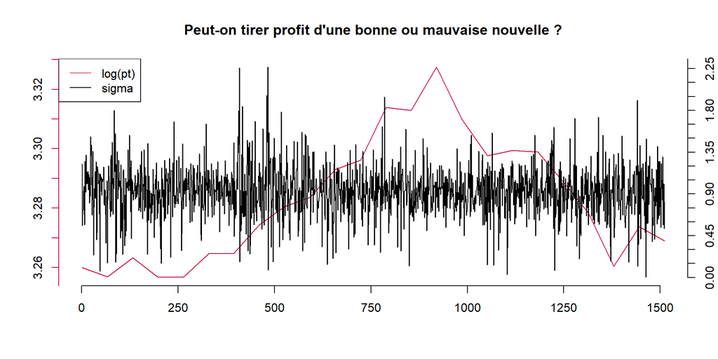

Figure 8.1: Logarithme de l’indice journalier et écart type récursif journalier des rendements

```r
sig <- rep(0,1534)
for(t in 1:1534){
  sig[t] <- sqrt(sum(rte[t-22]-(sum(rte[rt-22]/22)))^2/22)
}
sigma=sig[24:1534]*100
plot(log(pt[24:length(1534)]), type='l' ,col="#CC0033", axes=F, xlab="", ylab="")
axis(2,at=seq(3.25,3.34,by=0.01), col = "#CC0033")
par(new=T)
plot(sigma, col=1,type='l',axes = F,xlab="", ylab="")
axis(4,at=seq(0,3.25,by=0.15))
legend("topleft", c("log(pt)","sigma"),col = c(2, 1),lty=c(1,1))
axis(1,at=seq(0,1534,by=250))
title("Peut-on tirer profit d'une bonne ou mauvaise nouvelle ?")
```

2 pics pour l’écart type pour une valeur max de 2.25 vers 30% de la période. Le logarithme du prix est croissant jusqu’à 2/3 de la durée de la période, puis il décroit progressivement. Pour retomber à sa valeur initiale à 3.26. L’écart type semble fluctuer autour de 0.9. Il y a une dizaine de pics où l’écart type qui tend vers 0. Il y a donc des périodes très courtes où la volatilité est quasi-nulle. La plus grande volatilité correspond à une hausse, vers la date 500, dû à une bonne nouvelle. Néanmoins, cela n’est pas en lien avec la plus forte hausse. Ce modèle Garch ne modélise pas bien l’effet de levier. Il s’agira d’en trouver plus pertinent dans le prochain projet.

# 9 Annexe

## 9.1 Robustness check

Dans cette partie nous allons reprendre des tests réalisés auparavant mais en utilisant 1 seul lag significatif comme déterminé par par le critère BIC.

### 9.1.1 Zivot et Andrews

Les hypothèses sont les mêmes, (4.6),(4.7),(4.8)

```r
summary(ur.za(rte,model='both',lag=1))
```

```
##
## ################################
## # Zivot-Andrews Unit Root Test #
## ################################
##
##
## Call:
## lm(formula = testmat)
##
## Residuals:
##       Min        1Q    Median        3Q       Max
## -0.063561 -0.007210 -0.000346  0.006763  0.068473
##
## Coefficients:
##              Estimate Std. Error t value Pr(>|t|)
## (Intercept)  0.012822   0.006067   2.113  0.03473 *
## y.l1        -0.038960   0.036464  -1.068  0.28549
## trend       -0.001084   0.000378  -2.867  0.00420 **
## y.dl1        0.020106   0.025566   0.786  0.43172
## du           0.015351   0.005118   3.000  0.00275 **
## dt           0.001085   0.000378   2.870  0.00417 **
## ---
## Signif. codes:  0 '***' 0.001 '**' 0.01 '*' 0.05 '.' 0.1 ' ' 1
##
## Residual standard error: 0.01279 on 1526 degrees of freedom
##   (2 observations deleted due to missingness)
## Multiple R-squared:  0.007969,   Adjusted R-squared:  0.004718
## F-statistic: 2.452 on 5 and 1526 DF,  p-value: 0.03188
##
##
## Teststatistic: -28.4929
## Critical values: 0.01= -5.57 0.05= -5.08 0.1= -4.82
##
## Potential break point at position: 26
```

Nous utilisons cette fois un modèle avec un choc conjoncturel et structurel car les coefficients associés à du et dt sont significatif (<5%). Le lag n’est toujours pas significatif car sa t-value inférieure à 1,6. La statistique test vaut -28.49 et la statistique tabulée vaut -5.08 pour le seuil de 5%. Comme la statistique calculée est inférieure à la statistique tabulée, on n’acceptons pas $H_0$ la présence de racine unitaire sans changement structurel. Le choc potentiel est à la position 26, le 5 février 2010. On conclut à la stationnarité ici encore.

### 9.1.2 Lee et Strazicich

Selon les hypothèses (4.10) et (4.11)

```r
ur.ls(rte, model = "crash",breaks=1, lags=1, method = "GTOS", pn=0.1,print.results = "print")
```

```
## [1] -20.1509
## [1] "First possible structural break at position: 819"
## [1] "The location of the first break - lambda_1: 0.5 , with the number of total observations: 1534"
## Critical values - Crash model:
##          1%     5%    10%
## [1,] -4.239 -3.566 -3.211
## [1] "Number of lags determined by general-to-specific lag selection: 1"
## Runtime:
## Time difference of 0.05091424 mins
```

```
## [[1]]
## [[1]]$`t-stat`
## [1] -20.1509
##
## [[1]]$`First break`
## [1] 819
##
## [[1]]$Runtime
## Time difference of 0.05091424 mins
##
##
## [[2]]
##
## Call:
## lm(formula = y.diff ~ 0 + lagmatrix(S.tilde, 1)[, -1] + datmat[,
##     2:(slag + 2)] + Dt.diff)
##
## Residuals:
##       Min        1Q    Median        3Q       Max
## -0.053136 -0.008675 -0.000438  0.008328  0.067300
##
## Coefficients: (1 not defined because of singularities)
##                                         Estimate Std. Error t value Pr(>|t|)
## lagmatrix(S.tilde, 1)[, -1]           -0.6268023  0.0311054 -20.151  < 2e-16
## datmat[, 2:(slag + 2)]NoLags                  NA         NA      NA       NA
## datmat[, 2:(slag + 2)]S.tilde.diff.l1 -0.1856114  0.0251159  -7.390  2.4e-13
## Dt.diff1                               0.0063551  0.0004786  13.279  < 2e-16
## Dt.diff2                               0.0316034  0.0140792   2.245   0.0249
##
## lagmatrix(S.tilde, 1)[, -1]           ***
## datmat[, 2:(slag + 2)]NoLags
## datmat[, 2:(slag + 2)]S.tilde.diff.l1 ***
## Dt.diff1                              ***
## Dt.diff2                              *
## ---
## Signif. codes:  0 '***' 0.001 '**' 0.01 '*' 0.05 '.' 0.1 ' ' 1
##
## Residual standard error: 0.01406 on 1528 degrees of freedom
##   (2 observations deleted due to missingness)
## Multiple R-squared:  0.4065, Adjusted R-squared:  0.405
## F-statistic: 261.7 on 4 and 1528 DF,  p-value: < 2.2e-16
```

Notre unique lag a un coefficient significatif, il vaut -7,39 et est donc supérieur en sa valeur absolue à 1,6. La statistique calculée vaut -20,15, ce qui est inférieur à la statistique tabulée pour un risque de 5% qui vaut -3,566. On rejette l’hypothèse nulle de présence de racine unitaire sans changement structurel. Le choc est déterminé à la position 819, le 13 mars 2013. Ce test montre une nouvelle fois la stabilité de notre série.

## 9.2 Comparaison rte - rtt

```r
kable(data,caption = "Récapitulatif de l'analyse sur rte et comparaison avec rtt") %>%
  kable_styling(bootstrap_options = c("striped", "hover","condensed"),position = "float_right")%>%
  row_spec(c(3:4,8,11:14), bold = F,color = "green") %>%
  row_spec(c(2,6:7,10), bold = F,color = "orange") %>%
  row_spec(c(1,5,9), bold = F,color = "red") %>%
  pack_rows("Statistiques des données", 1, 3, label_row_css = "background-color: #666; color: #fff;") %>%
  pack_rows("Estimation d'un PGD", 10, 15, label_row_css = "background-color: #666; color: #fff;") %>%
  pack_rows("Tests de racine unitaire", 4, 9, label_row_css = "background-color: #666; color: #fff;")
```

Table 9.1: Récapitulatif de l’analyse sur rte et comparaison avec rtt

[output not shown]

correspondance

Correspondance moyenne

Mauvaise correspondance

Le BIC n’est pas comparable.  
Rapidement j’aimerai dire un petit mot sur les différences sur les tests de racine unitaire. Il y a des différences notables sur le nombre de lags significatifs, le type de modèle utilisé et aussi la non stationnarité avec le test de Lee et Strazicich pour rtt. Cela me rend un peu sceptique sur l’efficacité du backtesting pour le prochain projet. J’avais élicité dans le premier graphique (1.1) un changement dans la tendance du cours et dans sa fluctuation à partir de 2016. Or, c’est de cette façon que l’on a découpé notre série selon rte (avant 2016) et rtt (après 2016). Est-ce que l’on va pouvoir retrouver à partir de notre PGD estimé par rte cet accroissement de la valorisation boursière ?

## 9.3 Provenance des résultats sur rtt

```r
agostino.test(rtt)
```

```
##
##  D'Agostino skewness test
##
## data:  rtt
## skew = 0.057317, z = 0.752845, p-value = 0.4515
## alternative hypothesis: data have a skewness
```

```r
anscombe.test(rtt)
```

```
##
##  Anscombe-Glynn kurtosis test
##
## data:  rtt
## kurt = 8.1224, z = 11.0504, p-value < 2.2e-16
## alternative hypothesis: kurtosis is not equal to 3
```

```r
pvaluesrtt =rep(0,20)
pvaluesrtt2 =rep(0,20)
for (i in 1:25 ) {
pvaluesrtt[i] = Box.test(rtt,lag=i,type="Ljung-Box")$p.value
pvaluesrtt2[i] = Box.test(rtt^2,lag=i,type="Ljung-Box")$p.value
}
pvaluesrtt2
```

```
##  [1] 1.819354e-03 3.727684e-03 2.843415e-03 1.438702e-04 1.423262e-05
##  [6] 1.469171e-10 5.797340e-11 8.537571e-11 2.079231e-10 5.607359e-10
## [11] 1.364350e-09 3.029292e-09 2.992914e-09 3.010011e-09 5.752340e-09
## [16] 2.120526e-14 6.439294e-15 8.437695e-15 2.087219e-14 1.443290e-15
## [21] 3.330669e-15 0.000000e+00 0.000000e+00 0.000000e+00 0.000000e+00
```

```r
pvaluesrtt
```

```
##  [1] 0.24211465 0.48116459 0.68661538 0.40165818 0.44946141 0.38431541
##  [7] 0.40298873 0.30672690 0.28208875 0.13331998 0.18002126 0.21977612
## [13] 0.22138009 0.27279809 0.32166811 0.38753755 0.34721082 0.22870150
## [19] 0.23647894 0.13541898 0.09741232 0.09068372 0.10365637 0.11147339
## [25] 0.13826575
```

```r
summary(ur.df(rtt,type='none',lags=0))
```

```
##
## ###############################################
## # Augmented Dickey-Fuller Test Unit Root Test #
## ###############################################
##
## Test regression none
##
##
## Call:
## lm(formula = z.diff ~ z.lag.1 - 1)
##
## Residuals:
##       Min        1Q    Median        3Q       Max
## -0.077919 -0.005925  0.000588  0.006795  0.075671
##
## Coefficients:
##         Estimate Std. Error t value Pr(>|t|)
## z.lag.1 -0.96214    0.03124   -30.8   <2e-16 ***
## ---
## Signif. codes:  0 '***' 0.001 '**' 0.01 '*' 0.05 '.' 0.1 ' ' 1
##
## Residual standard error: 0.01301 on 1020 degrees of freedom
## Multiple R-squared:  0.4818, Adjusted R-squared:  0.4813
## F-statistic: 948.4 on 1 and 1020 DF,  p-value: < 2.2e-16
##
##
## Value of test-statistic is: -30.7959
##
## Critical values for test statistics:
##       1pct  5pct 10pct
## tau1 -2.58 -1.95 -1.62
```

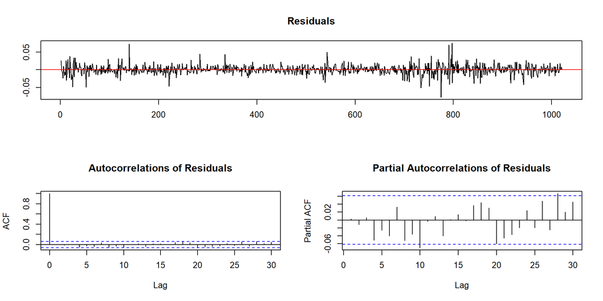

```r
plot(ur.df(rtt,lag=0,type='none'))
```

```r
schwert2 <- as.integer(12*(length(rtt)/100)^0.25)
summary(CADFtest(rtt,criterion="MAIC",type="none",max.lag.y=schwert2))
```

```
## Augmented DF test
##                                                 ADF test
## t-test statistic:                          -1.786523e+01
## p-value:                                    4.968631e-37
## Max lag of the diff. dependent variable:    2.000000e+00
##
## Call:
## dynlm(formula = formula(model), start = obs.1, end = obs.T)
##
## Residuals:
##       Min        1Q    Median        3Q       Max
## -0.078028 -0.005962  0.000565  0.006666  0.075868
##
## Coefficients:
##             Estimate Std. Error t value Pr(>|t|)
## L(y, 1)    -0.948855   0.053112 -17.865   <2e-16 ***
## L(d(y), 1) -0.003665   0.043606  -0.084    0.933
## L(d(y), 2) -0.011850   0.031531  -0.376    0.707
## ---
## Signif. codes:  0 '***' 0.001 '**' 0.01 '*' 0.05 '.' 0.1 ' ' 1
##
## Residual standard error: 0.01289 on 997 degrees of freedom
## Multiple R-squared:  0.4766, Adjusted R-squared:  0.4751
## F-statistic: 0.09944 on 2 and 997 DF,  p-value: 0.9054
```

```r
summary(ur.df(rtt,type='none',lags=2))
```

```
##
## ###############################################
## # Augmented Dickey-Fuller Test Unit Root Test #
## ###############################################
##
## Test regression none
##
##
## Call:
## lm(formula = z.diff ~ z.lag.1 - 1 + z.diff.lag)
##
## Residuals:
##       Min        1Q    Median        3Q       Max
## -0.077928 -0.005977  0.000566  0.006751  0.075972
##
## Coefficients:
##              Estimate Std. Error t value Pr(>|t|)
## z.lag.1     -0.962172   0.052982 -18.160   <2e-16 ***
## z.diff.lag1  0.004133   0.043419   0.095    0.924
## z.diff.lag2 -0.006218   0.031269  -0.199    0.842
## ---
## Signif. codes:  0 '***' 0.001 '**' 0.01 '*' 0.05 '.' 0.1 ' ' 1
##
## Residual standard error: 0.01301 on 1016 degrees of freedom
## Multiple R-squared:  0.4793, Adjusted R-squared:  0.4778
## F-statistic: 311.8 on 3 and 1016 DF,  p-value: < 2.2e-16
##
##
## Value of test-statistic is: -18.1603
##
## Critical values for test statistics:
##       1pct  5pct 10pct
## tau1 -2.58 -1.95 -1.62
```

```r
summary(ur.df(rtt,type='none',selectlags = "BIC"))
```

```
##
## ###############################################
## # Augmented Dickey-Fuller Test Unit Root Test #
## ###############################################
##
## Test regression none
##
##
## Call:
## lm(formula = z.diff ~ z.lag.1 - 1 + z.diff.lag)
##
## Residuals:
##       Min        1Q    Median        3Q       Max
## -0.077827 -0.005936  0.000576  0.006766  0.075943
##
## Coefficients:
##             Estimate Std. Error t value Pr(>|t|)
## z.lag.1    -0.968235   0.043362 -22.329   <2e-16 ***
## z.diff.lag  0.009899   0.031238   0.317    0.751
## ---
## Signif. codes:  0 '***' 0.001 '**' 0.01 '*' 0.05 '.' 0.1 ' ' 1
##
## Residual standard error: 0.013 on 1018 degrees of freedom
## Multiple R-squared:  0.4803, Adjusted R-squared:  0.4793
## F-statistic: 470.4 on 2 and 1018 DF,  p-value: < 2.2e-16
##
##
## Value of test-statistic is: -22.3289
##
## Critical values for test statistics:
##       1pct  5pct 10pct
## tau1 -2.58 -1.95 -1.62
```

```r
summary(ur.df(rtt,type='none',lags=schwert2-2))
```

```
##
## ###############################################
## # Augmented Dickey-Fuller Test Unit Root Test #
## ###############################################
##
## Test regression none
##
##
## Call:
## lm(formula = z.diff ~ z.lag.1 - 1 + z.diff.lag)
##
## Residuals:
##       Min        1Q    Median        3Q       Max
## -0.069701 -0.005622  0.000544  0.006834  0.073568
##
## Coefficients:
##               Estimate Std. Error t value Pr(>|t|)
## z.lag.1      -1.113095   0.154217  -7.218 1.06e-12 ***
## z.diff.lag1   0.160388   0.150483   1.066   0.2868
## z.diff.lag2   0.151933   0.146570   1.037   0.3002
## z.diff.lag3   0.168118   0.142153   1.183   0.2372
## z.diff.lag4   0.102128   0.137276   0.744   0.4571
## z.diff.lag5   0.067794   0.132086   0.513   0.6079
## z.diff.lag6   0.036446   0.126497   0.288   0.7733
## z.diff.lag7   0.090455   0.120668   0.750   0.4537
## z.diff.lag8   0.029046   0.114957   0.253   0.8006
## z.diff.lag9   0.004310   0.108661   0.040   0.9684
## z.diff.lag10 -0.064818   0.102070  -0.635   0.5256
## z.diff.lag11 -0.050171   0.095813  -0.524   0.6007
## z.diff.lag12 -0.033142   0.089508  -0.370   0.7113
## z.diff.lag13 -0.073011   0.083292  -0.877   0.3809
## z.diff.lag14 -0.069816   0.076089  -0.918   0.3591
## z.diff.lag15 -0.048715   0.068797  -0.708   0.4791
## z.diff.lag16 -0.051240   0.060985  -0.840   0.4010
## z.diff.lag17 -0.005797   0.053045  -0.109   0.9130
## z.diff.lag18  0.029590   0.043414   0.682   0.4957
## z.diff.lag19  0.060816   0.031185   1.950   0.0514 .
## ---
## Signif. codes:  0 '***' 0.001 '**' 0.01 '*' 0.05 '.' 0.1 ' ' 1
##
## Residual standard error: 0.0128 on 982 degrees of freedom
## Multiple R-squared:  0.4934, Adjusted R-squared:  0.4831
## F-statistic: 47.82 on 20 and 982 DF,  p-value: < 2.2e-16
##
##
## Value of test-statistic is: -7.2177
##
## Critical values for test statistics:
##       1pct  5pct 10pct
## tau1 -2.58 -1.95 -1.62
```

```r
summary(ur.za(rtt, model='intercept', lag = schwert2-1))
```

```
##
## ################################
## # Zivot-Andrews Unit Root Test #
## ################################
##
##
## Call:
## lm(formula = testmat)
##
## Residuals:
##       Min        1Q    Median        3Q       Max
## -0.068621 -0.006123  0.000056  0.006593  0.072497
##
## Coefficients:
##               Estimate Std. Error t value Pr(>|t|)
## (Intercept)  2.103e-03  9.824e-04   2.141  0.03251 *
## y.l1        -3.153e-01  1.666e-01  -1.892  0.05874 .
## trend       -4.376e-06  2.103e-06  -2.081  0.03771 *
## y.dl1        3.510e-01  1.620e-01   2.167  0.03050 *
## y.dl2        3.370e-01  1.577e-01   2.137  0.03282 *
## y.dl3        3.482e-01  1.532e-01   2.272  0.02328 *
## y.dl4        2.771e-01  1.483e-01   1.868  0.06206 .
## y.dl5        2.345e-01  1.429e-01   1.641  0.10112
## y.dl6        1.952e-01  1.371e-01   1.424  0.15489
## y.dl7        2.414e-01  1.309e-01   1.844  0.06553 .
## y.dl8        1.719e-01  1.246e-01   1.379  0.16811
## y.dl9        1.395e-01  1.184e-01   1.177  0.23930
## y.dl10       6.223e-02  1.116e-01   0.557  0.57734
## y.dl11       6.518e-02  1.045e-01   0.624  0.53302
## y.dl12       7.279e-02  9.776e-02   0.745  0.45670
## y.dl13       2.293e-02  9.104e-02   0.252  0.80121
## y.dl14       1.921e-02  8.445e-02   0.227  0.82009
## y.dl15       3.223e-02  7.696e-02   0.419  0.67546
## y.dl16       2.298e-02  6.941e-02   0.331  0.74065
## y.dl17       6.007e-02  6.140e-02   0.978  0.32818
## y.dl18       9.052e-02  5.328e-02   1.699  0.08967 .
## y.dl19       1.149e-01  4.353e-02   2.640  0.00843 **
## y.dl20       5.045e-02  3.125e-02   1.614  0.10676
## du           3.591e-03  1.448e-03   2.479  0.01333 *
## ---
## Signif. codes:  0 '***' 0.001 '**' 0.01 '*' 0.05 '.' 0.1 ' ' 1
##
## Residual standard error: 0.01276 on 977 degrees of freedom
##   (21 observations deleted due to missingness)
## Multiple R-squared:  0.04064,    Adjusted R-squared:  0.01805
## F-statistic: 1.799 on 23 and 977 DF,  p-value: 0.01195
##
##
## Teststatistic: -7.8942
## Critical values: 0.01= -5.34 0.05= -4.8 0.1= -4.58
##
## Potential break point at position: 790
```

```r
ur.ls(rtt, model = "crash",breaks=1, lags=17, method = "GTOS", pn=0.1,print.results = "print")
```

```
## [1] -3.317547
## [1] "First possible structural break at position: 125"
## [1] "The location of the first break - lambda_1: 0.1 , with the number of total observations: 1022"
## Critical values - Crash model:
##          1%     5%    10%
## [1,] -4.239 -3.566 -3.211
## [1] "Number of lags determined by general-to-specific lag selection: 17"
## Runtime:
## Time difference of 0.06136962 mins
```

```
## [[1]]
## [[1]]$`t-stat`
## [1] -3.317547
##
## [[1]]$`First break`
## [1] 125
##
## [[1]]$Runtime
## Time difference of 0.06136962 mins
##
##
## [[2]]
##
## Call:
## lm(formula = y.diff ~ 0 + lagmatrix(S.tilde, 1)[, -1] + datmat[,
##     2:(slag + 2)] + Dt.diff)
##
## Residuals:
##       Min        1Q    Median        3Q       Max
## -0.073400 -0.007074  0.000126  0.006597  0.070524
##
## Coefficients: (1 not defined because of singularities)
##                                          Estimate Std. Error t value Pr(>|t|)
## lagmatrix(S.tilde, 1)[, -1]            -0.1856962  0.0559740  -3.318 0.000941
## datmat[, 2:(slag + 2)]NoLags                   NA         NA      NA       NA
## datmat[, 2:(slag + 2)]S.tilde.diff.l1  -0.7295817  0.0611676 -11.928  < 2e-16
## datmat[, 2:(slag + 2)]S.tilde.diff.l2  -0.6910236  0.0645960 -10.698  < 2e-16
## datmat[, 2:(slag + 2)]S.tilde.diff.l3  -0.6259622  0.0672980  -9.301  < 2e-16
## datmat[, 2:(slag + 2)]S.tilde.diff.l4  -0.6366872  0.0687783  -9.257  < 2e-16
## datmat[, 2:(slag + 2)]S.tilde.diff.l5  -0.6142209  0.0699931  -8.775  < 2e-16
## datmat[, 2:(slag + 2)]S.tilde.diff.l6  -0.5955237  0.0708227  -8.409  < 2e-16
## datmat[, 2:(slag + 2)]S.tilde.diff.l7  -0.5043789  0.0709040  -7.114 2.17e-12
## datmat[, 2:(slag + 2)]S.tilde.diff.l8  -0.5067367  0.0697863  -7.261 7.78e-13
## datmat[, 2:(slag + 2)]S.tilde.diff.l9  -0.4826914  0.0687300  -7.023 4.05e-12
## datmat[, 2:(slag + 2)]S.tilde.diff.l10 -0.4994559  0.0673140  -7.420 2.53e-13
## datmat[, 2:(slag + 2)]S.tilde.diff.l11 -0.4410523  0.0659070  -6.692 3.69e-11
## datmat[, 2:(slag + 2)]S.tilde.diff.l12 -0.3679198  0.0629845  -5.841 7.03e-09
## datmat[, 2:(slag + 2)]S.tilde.diff.l13 -0.3543552  0.0592712  -5.979 3.15e-09
## datmat[, 2:(slag + 2)]S.tilde.diff.l14 -0.3040504  0.0547427  -5.554 3.59e-08
## datmat[, 2:(slag + 2)]S.tilde.diff.l15 -0.2409773  0.0494813  -4.870 1.30e-06
```

[output cut: 18 more lines]

```
## datmat[, 2:(slag + 2)]S.tilde.diff.l12 ***
## datmat[, 2:(slag + 2)]S.tilde.diff.l13 ***
## datmat[, 2:(slag + 2)]S.tilde.diff.l14 ***
## datmat[, 2:(slag + 2)]S.tilde.diff.l15 ***
## datmat[, 2:(slag + 2)]S.tilde.diff.l16 ***
## datmat[, 2:(slag + 2)]S.tilde.diff.l17 **
## Dt.diff1
## Dt.diff2                               **
## ---
## Signif. codes:  0 '***' 0.001 '**' 0.01 '*' 0.05 '.' 0.1 ' ' 1
##
## Residual standard error: 0.01319 on 984 degrees of freedom
##   (18 observations deleted due to missingness)
## Multiple R-squared:  0.4683, Adjusted R-squared:  0.4575
## F-statistic: 43.33 on 20 and 984 DF,  p-value: < 2.2e-16
```

```r
eacf(rtt)
```

```
## AR/MA
##   0 1 2 3 4 5 6 7 8 9 10 11 12 13
## 0 o o o o o o o o o o o  o  o  o
## 1 x o o o o o o o o o o  o  o  o
## 2 x o o o o o o o o x o  o  o  o
## 3 x x x o o o o o o x o  o  o  o
## 4 x x x o o o o o o x o  o  o  o
## 5 x x x x x o o o o x o  o  o  o
## 6 x x x x x x o o o x o  o  o  o
## 7 x x x x x x x o o o o  o  o  o
```

```r
reg2 <- stats::arima(rtt, order = c(1,0,1),include.mean = FALSE)
coeftest(reg2)
```

```
##
## z test of coefficients:
##
##      Estimate Std. Error z value  Pr(>|z|)
## ar1 -0.803247   0.107747 -7.4549 8.993e-14 ***
## ma1  0.839370   0.097961  8.5684 < 2.2e-16 ***
## ---
## Signif. codes:  0 '***' 0.001 '**' 0.01 '*' 0.05 '.' 0.1 ' ' 1
```

```r
residu2 <- reg2$res
t.test(residu2)
```

```
##
##  One Sample t-test
##
## data:  residu2
## t = 1.1374, df = 1021, p-value = 0.2557
## alternative hypothesis: true mean is not equal to 0
## 95 percent confidence interval:
##  -0.0003356001  0.0012609998
## sample estimates:
##    mean of x
## 0.0004626999
```

```r
residuv2=(residu2-mean(residu2))/sd(residu2)
K <- 22
tmp2<-rep(0,K)
for(i in 1:K){
tmp2[i]<-Box.test(residuv2,lag=i,type="Ljung-Box")$p.value
}
tmp2
```

```
##  [1] 0.9173543 0.8658424 0.9043839 0.8066745 0.6875896 0.6864650 0.7341980
##  [8] 0.6558622 0.5668755 0.3611665 0.4328911 0.4768475 0.4535309 0.5136151
## [15] 0.5769635 0.6457491 0.6104580 0.4427712 0.4595168 0.3201464 0.2365094
## [22] 0.2348895
```

```r
LM2 <- rep(0,22)
for (i in 1:22){
  LM2[[i]] = ArchTest(as.numeric(rtt),lags=i)$p.value
}
LM2
```

```
##  [1] 1.850359e-03 5.593994e-03 5.356728e-03 6.108775e-04 2.142689e-04
##  [6] 4.386473e-08 7.909779e-08 1.921442e-07 4.795069e-07 8.659777e-07
## [11] 1.804821e-06 1.370455e-06 1.905574e-06 2.727910e-06 5.150214e-06
## [16] 1.446168e-11 1.172402e-11 1.520446e-11 3.210805e-11 3.957173e-11
## [21] 4.154583e-11 3.346072e-13
```

```r
volat2 <- garch(residuv2,order = c(1,1))
```

```
##
##  ***** ESTIMATION WITH ANALYTICAL GRADIENT *****
##
##
##      I     INITIAL X(I)        D(I)
##
##      1     9.000000e-01     1.000e+00
##      2     5.000000e-02     1.000e+00
##      3     5.000000e-02     1.000e+00
##
##     IT   NF      F         RELDF    PRELDF    RELDX   STPPAR   D*STEP   NPRELDF
##      0    1  4.988e+02
##      1    3  4.952e+02  7.26e-03  1.94e-02  5.5e-02  9.7e+02  1.0e-01  9.35e+00
##      2    5  4.948e+02  9.11e-04  1.00e-03  4.6e-03  2.1e+01  1.0e-02  2.64e+00
##      3    6  4.942e+02  1.16e-03  1.18e-03  1.0e-02  2.9e+00  2.0e-02  2.28e-01
```

[output cut: 44 more lines]

```r
summary(volat2)
```

```
##
## Call:
## garch(x = residuv2, order = c(1, 1))
##
## Model:
## GARCH(1,1)
##
## Residuals:
##        Min         1Q     Median         3Q        Max
## -4.7863571 -0.5343006  0.0005664  0.5241954  6.4683841
##
## Coefficient(s):
##     Estimate  Std. Error  t value Pr(>|t|)
## a0  0.019621    0.004753    4.128 3.66e-05 ***
## a1  0.050293    0.008046    6.251 4.08e-10 ***
## b1  0.929574    0.010152   91.568  < 2e-16 ***
## ---
## Signif. codes:  0 '***' 0.001 '**' 0.01 '*' 0.05 '.' 0.1 ' ' 1
##
## Diagnostic Tests:
##  Jarque Bera Test
##
## data:  Residuals
## X-squared = 600.81, df = 2, p-value < 2.2e-16
##
##
##  Box-Ljung test
##
## data:  Squared.Residuals
## X-squared = 0.09844, df = 1, p-value = 0.7537
```

```r
H2 <- rep(0,K)
for(i in 1:K){
  H2[[i]] = ArchTest(volat2$residuals,lags = i)$p.value
}
H2
```

```
##  [1] 0.7540193 0.4002640 0.6015998 0.6170305 0.7507602 0.8249947 0.8992713
##  [8] 0.9364025 0.9611982 0.9372865 0.8911559 0.7266431 0.7944761 0.8300829
## [15] 0.8646839 0.6740135 0.7314883 0.6945492 0.6720042 0.7338931 0.7473316
## [22] 0.6863485
```

```r
anscombe.test(volat2$residuals)
```

```
##
##  Anscombe-Glynn kurtosis test
##
## data:  volat2$residuals
## kurt = 6.7494, z = 9.7214, p-value < 2.2e-16
## alternative hypothesis: kurtosis is not equal to 3
```

```r
BIC(reg2)
```

```
## [1] -5954.42
```